# SpotifyFinalProject

## **Spotify Song Predictor**

### **Predicting the Popularity of a Song**

By: Esha Singhai, Eshita Mehrotra, Sheena Agrawal

### **1. Introduction**

Spotify is a digital music service that provides access to millions of songs and other content from artists all over the world. It has become a cornerstone of the music industry, offering a platform where both established and emerging artists can reach a global audience. With its vast amount of data on songs, artists, and user interactions, Spotify presents a rich dataset for analysis.

In this project, we aim to explore the question of whether we can predict the popularity of a song based on various musical features. By leveraging data science and machine learning methods, we seek to identify key factors that contribute to a song's success and build a model that can forecast the popularity of future songs. This analysis will help us understand trends in the music industry and provide insights that could guide artists and producers in creating music that resonates with a wide audience.

### **2. Data Curation, Parsing, and Management**

For our project, we utilized the Spotify Tracks Dataset, which is a comprehensive collection of songs from Spotify, spanning a wide range of 125 different genres. Each track in this dataset is associated with various audio features that are instrumental in our analysis and model building.

The dataset is publicly available and was obtained using Spotify's Web API and Python, ensuring that the data is both reliable and well-structured. Below is an overview of the process we followed to load and prepare the data for our project.

#### 2.1 Imports

We will be using the pandas library throughout our analysis, so that we can put our data into a dataframe format. The most efficient way to install pandas is through the [Anaconda distribution](https://docs.continuum.io/free/anaconda/).

```python
import pandas as pd
from datasets import load_dataset
```

#### 2.2 Loading in the Data

The data we will be using is the "Spotify Tracks Dataset", which was collected from Spotify's Web API. It can be found [here](https://huggingface.co/datasets/maharshipandya/spotify-tracks-dataset).

```python
dataset = load_dataset("maharshipandya/spotify-tracks-dataset")
split_name = 'train'
df = pd.DataFrame(dataset[split_name])
```

[output not shown]

#### 2.3 Tidy Data

Before we can perform any meaningful analysis or modeling, it is crucial to tidy and preprocess the data. This involves handling missing values, encoding categorical variables, normalizing numerical features, and ensuring the dataset is in a suitable format for machine learning algorithms. Below are the steps we will follow to tidy the data.

```python
# Checking for missing values
print(df.isnull().sum())

# Handling missing values by filling them with appropriate values or dropping them
df = df.dropna(subset=['artists', 'album_name', 'track_name'])

# Convert milliseconds to minutes
df['duration_min'] = df['duration_ms'] / 60000
```

```
Unnamed: 0          0
track_id            0
artists             1
album_name          1
track_name          1
popularity          0
duration_ms         0
explicit            0
danceability        0
energy              0
key                 0
loudness            0
mode                0
speechiness         0
acousticness        0
instrumentalness    0
liveness            0
valence             0
tempo               0
time_signature      0
track_genre         0
dtype: int64
```

To ensure that all numerical features contribute equally to the analysis, we should normalize or scale them. StandardScaler from scikit-learn can be used for this purpose.

```python
from sklearn.preprocessing import StandardScaler

# Selecting numerical features for scaling
numerical_features = ['danceability', 'energy', 'loudness', 'speechiness', 'acousticness',
                      'instrumentalness', 'liveness', 'valence', 'tempo', 'duration_ms']

# Initializing the scaler
scaler = StandardScaler()

# Scaling the numerical features
df[numerical_features] = scaler.fit_transform(df[numerical_features])
```

We should also ensure that there are no duplicate rows and that all columns are in the correct data type.

```python
# Removing duplicate rows
df = df.drop_duplicates()

# Ensuring correct data types
df['popularity'] = df['popularity'].astype(int)
df['explicit'] = df['explicit'].astype(bool)
df['key'] = df['key'].astype(int)
df['mode'] = df['mode'].astype(int)
df.head()
```

|  | Unnamed: 0 | track_id | artists | album_name | track_name | popularity | duration_ms | explicit | danceability | energy | ... | mode | speechiness | acousticness | instrumentalness | liveness | valence | tempo | time_signature | track_genre | duration_min |
| --- | --- | --- | --- | --- | --- | --- | --- | --- | --- | --- | --- | --- | --- | --- | --- | --- | --- | --- | --- | --- | --- |
| 0 | 0 | 5SuOikwiRyPMVoIQDJUgSV | Gen Hoshino | Comedy | Comedy | 73 | 0.024557 | False | 0.629239 | -0.717147 | ... | 0 | 0.551843 | -0.850193 | -0.504111 | 0.758735 | 0.929315 | -1.141854 | 4 | acoustic | 3.844433 |
| 1 | 1 | 4qPNDBW1i3p13qLCt0Ki3A | Ben Woodward | Ghost (Acoustic) | Ghost - Acoustic | 55 | -0.730889 | False | -0.845908 | -1.889974 | ... | 1 | -0.078995 | 1.831744 | -0.504097 | -0.591216 | -0.798681 | -1.489708 | 4 | acoustic | 2.493500 |
| 2 | 2 | 1iJBSr7s7jYXzM8EGcbK5b | Ingrid Michaelson;ZAYN | To Begin Again | To Begin Again | 57 | -0.160353 | False | -0.742187 | -1.122667 | ... | 1 | -0.273827 | -0.315489 | -0.504115 | -0.507172 | -1.365679 | -1.528303 | 4 | acoustic | 3.513767 |
| 3 | 3 | 6lfxq3CG4xtTiEg7opyCyx | Kina Grannis | Crazy Rich Asians (Original Motion Picture Sou... | Can't Help Falling In Love | 71 | -0.243236 | False | -1.733301 | -2.312987 | ... | 1 | -0.457309 | 1.774605 | -0.503886 | -0.428381 | -1.276965 | 1.987857 | 3 | acoustic | 3.365550 |
| 4 | 4 | 5vjLSffimiIP26QG5WcN2K | Chord Overstreet | Hold On | Hold On | 82 | -0.271942 | False | 0.295026 | -0.788709 | ... | 1 | -0.303146 | 0.463409 | -0.504115 | -0.686290 | -1.184394 | -0.073343 | 4 | acoustic | 3.314217 |

5 rows × 22 columns

By tidying the data in this manner, we ensure that our dataset is well-prepared for the subsequent steps of analysis and machine learning model training. This preparation is crucial for obtaining accurate and meaningful results from our predictive models.

### **3. Exploratory Data Analysis (EDA)**

In this exploratory analysis section, we embark on a journey through the Spotify Tracks Dataset to uncover insights into the factors influencing a song's popularity. Our dataset comprises a wealth of information, including audio features, genre classifications, and popularity ratings for a diverse range of songs available on Spotify.

Through a series of analyses, we aim to dissect the relationships between various musical features and the popularity of songs. Our goal is to identify patterns, trends, and correlations that may offer valuable insights into the dynamics of the music industry and the preferences of listeners.

By examining the distribution of key attributes, exploring correlations between variables, and visualizing trends over time, we endeavor to gain a comprehensive understanding of what makes a song resonate with audiences. Our findings will not only inform our predictive modeling efforts but also provide actionable insights for artists, producers, and industry professionals seeking to optimize their creative endeavors for maximum impact and engagement.

#### 3.1 Imports

We will primarily be using matplotlib.pyplot and seaborn for the data visualizations, as they will help us in creating visually appealing stastics. Below is an overview of how to download these libraries:

*Matplotlib:*

- python -m pip install -U pip
- python -m pip install -U matplotlib

*Seaborn:*

- pip install seaborn

```python
import matplotlib.pyplot as plt
import seaborn as sns
```

#### 3.2 Pie chart of Top 10 most popular genres

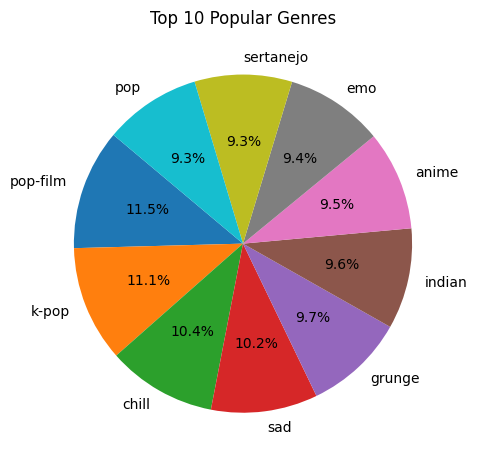

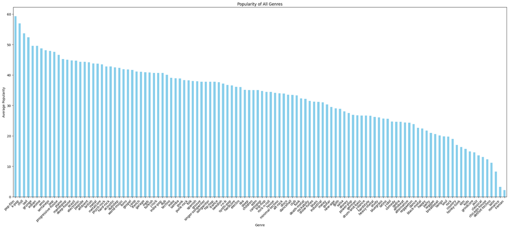

```python
# Group by genre and calculate mean popularity
genre_popularity = df.groupby('track_genre')['popularity'].mean()

# Sort by popularity
genre_popularity = genre_popularity.sort_values(ascending=False)

top_5 = genre_popularity.head(10)

plt.figure(figsize=(12, 6))
plt.subplot(1, 2, 1)
plt.pie(top_5, labels=top_5.index, autopct='%1.1f%%', startangle=140)
plt.title('Top 10 Popular Genres')

plt.show()

# Group by genre and calculate mean popularity
genre_popularity = df.groupby('track_genre')['popularity'].mean()

# Sort by popularity
genre_popularity_sorted = genre_popularity.sort_values(ascending=False)

# Plotting all genres as a bar chart
plt.figure(figsize=(22, 10))  # Adjusted for better display of numerous categories
genre_popularity_sorted.plot(kind='bar', color='skyblue')
plt.title('Popularity of All Genres')
plt.ylabel('Average Popularity')
plt.xlabel('Genre')
plt.xticks(rotation=45, ha='right')  # Rotate genre names for better readability
plt.tight_layout()  # Adjust layout to make room for label rotation

plt.show()
```

The pie chart above shows the top 10 most popular genres and the bar graph shows the popularity of every genre in dataset. Based on the graphs, we can see that pop film is the most popular genre within songs. The analysis of genre popularity can be integrated into our model to enhance the prediction of high versus low popularity songs. By understanding which genres are more popular, we can incorporate genre as a predictive feature, allowing the model to account for the inherent popularity trends within different musical styles. This will improve the model's accuracy in distinguishing between high and low popularity tracks.

#### 3.3 Polynomial Regression of Average Popularity by Duration Interval

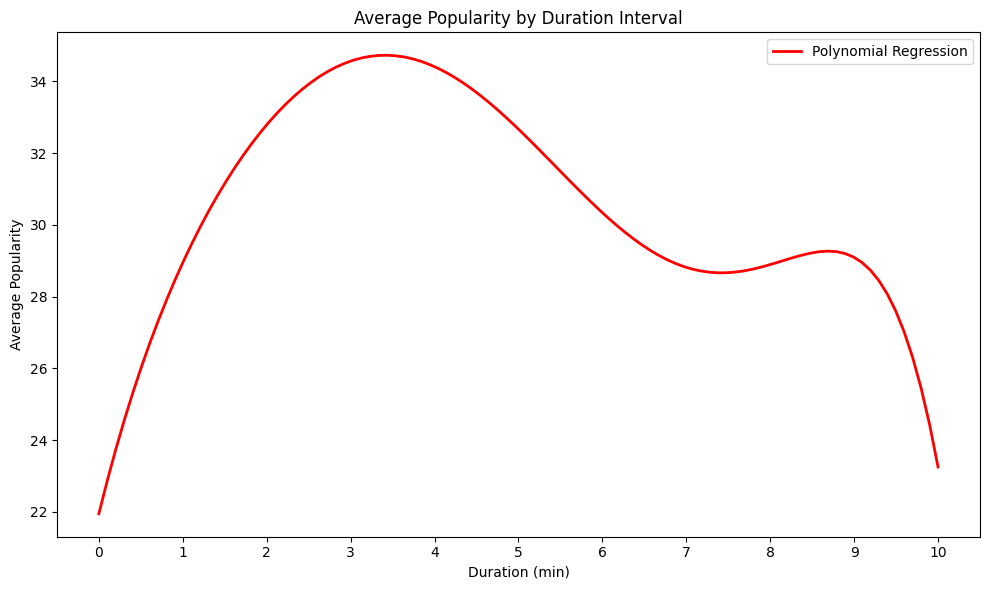

```python
import numpy as np
import pandas as pd
import matplotlib.pyplot as plt
from sklearn.preprocessing import PolynomialFeatures
from sklearn.linear_model import LinearRegression

# Define intervals for duration_min
intervals = np.arange(0, 12, 1)

# Assign each row to an interval
df['duration_interval'] = pd.cut(df['duration_min'], bins=intervals, right=False)

# Calculate average popularity for each interval
interval_popularity = df.groupby('duration_interval')['popularity'].mean().reset_index()

# Extract numerical values from duration intervals
x = np.arange(len(interval_popularity))

# Fit polynomial regression
poly_features = PolynomialFeatures(degree=6)
X_poly = poly_features.fit_transform(x.reshape(-1, 1))
poly_model = LinearRegression()
poly_model.fit(X_poly, interval_popularity['popularity'])

# Plotting
plt.figure(figsize=(10, 6))
plt.title('Average Popularity by Duration Interval')
plt.xlabel('Duration (min)')
plt.ylabel('Average Popularity')
plt.grid(axis='y', linestyle='--', alpha=0.7)

# Plot polynomial regression line
x_values = np.linspace(0, len(interval_popularity) - 1, 100)
x_values_poly = poly_features.transform(x_values.reshape(-1, 1))
plt.plot(x_values, poly_model.predict(x_values_poly), color='red', linestyle='-', linewidth=2, label='Polynomial Regression')

# Set x-axis ticks
plt.xticks(np.arange(0, len(interval_popularity)), np.arange(0, 11))

plt.legend()
plt.tight_layout()
plt.grid(False)
plt.show()
```

This analysis reveals that tracks with durations between 3 and 4 minutes tend to be the most popular on average. This insight can be particularly valuable for artists and producers aiming to maximize the popularity of their tracks. Understanding the optimal duration for popular tracks can guide decisions in the music creation process, potentially leading to higher listener engagement and better chart performance.

#### 3.4 Plots to Analyze Trends about Key/Mode on Collaborations

In this section, we analyze the relationship between the musical key and mode of tracks and their average popularity. By grouping tracks by their key and mode, we can observe how these musical attributes influence popularity scores.

First, we group the data by key and mode and calculate the average popularity for each group. To make the data more interpretable, we map the integer values representing keys and modes to their corresponding musical notations and descriptions:

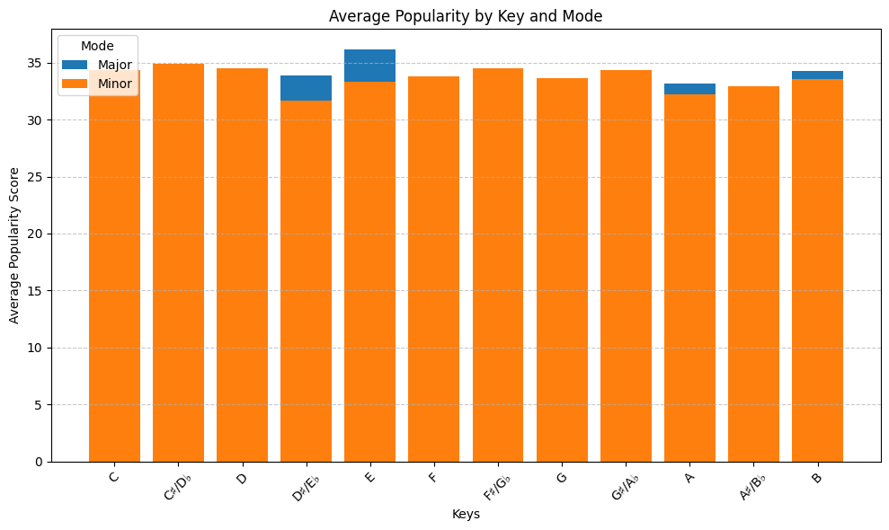

```python
# Grouping the data by key and mode and calculating the average popularity
average_popularity = df.groupby(['key', 'mode'])['popularity'].mean().reset_index()

# Mapping the integer keys to their corresponding pitch class notation
key_mapping = {
    0: 'C',
    1: 'C♯/D♭',
    2: 'D',
    3: 'D♯/E♭',
    4: 'E',
    5: 'F',
    6: 'F♯/G♭',
    7: 'G',
    8: 'G♯/A♭',
    9: 'A',
    10: 'A♯/B♭',
    11: 'B'
}

# Mapping the mode values to 'Major' and 'Minor'
mode_mapping = {1: 'Major', 0: 'Minor'}

# Applying the mappings to the DataFrame
average_popularity['key'] = average_popularity['key'].map(key_mapping)
average_popularity['mode'] = average_popularity['mode'].map(mode_mapping)

# Plotting the bar chart
plt.figure(figsize=(10, 6))
for mode, group_data in average_popularity.groupby('mode'):
    plt.bar(group_data['key'], group_data['popularity'], label=mode)

plt.xlabel('Keys')
plt.ylabel('Average Popularity Score')
plt.title('Average Popularity by Key and Mode')
plt.legend(title='Mode')
plt.xticks(rotation=45)
plt.grid(axis='y', linestyle='--', alpha=0.7)

plt.tight_layout()
plt.show()
```

From the bar chart above, we can deduce that the average popularity scores are relatively consistent across most keys, with values generally ranging between 30 and 36. No single key stands out as having an exceptionally high or low average popularity, suggesting that key alone is not a major determinant of a track's popularity.

In conclusion, the analysis of average popularity by key and mode reveals that while there are some differences between major and minor modes, these differences are not dramatic. The preference for certain keys or modes does not significantly sway the popularity scores. This suggests that other musical features or external factors, such as lyrics, artist popularity, and marketing, might have a more substantial impact on a track's popularity.

For musicians and producers, this insight means that while choosing a key and mode is important, focusing on a combination of various musical elements and external influences might be more critical for creating popular tracks.

#### 3.5 Heatmap Exploring Key, Mode, and Popularity

Here, we group the data by three attributes: 'key', 'mode', and 'track_genre', calculating the mean popularity within each group. Then, it pivots this grouped data into a format suitable for a heatmap, with 'mode' as rows, 'key' as columns, and 'popularity' as values. Finally, it plots the heatmap using seaborn, with annotations showing the average popularity values. Axes labels and the title are customized accordingly.

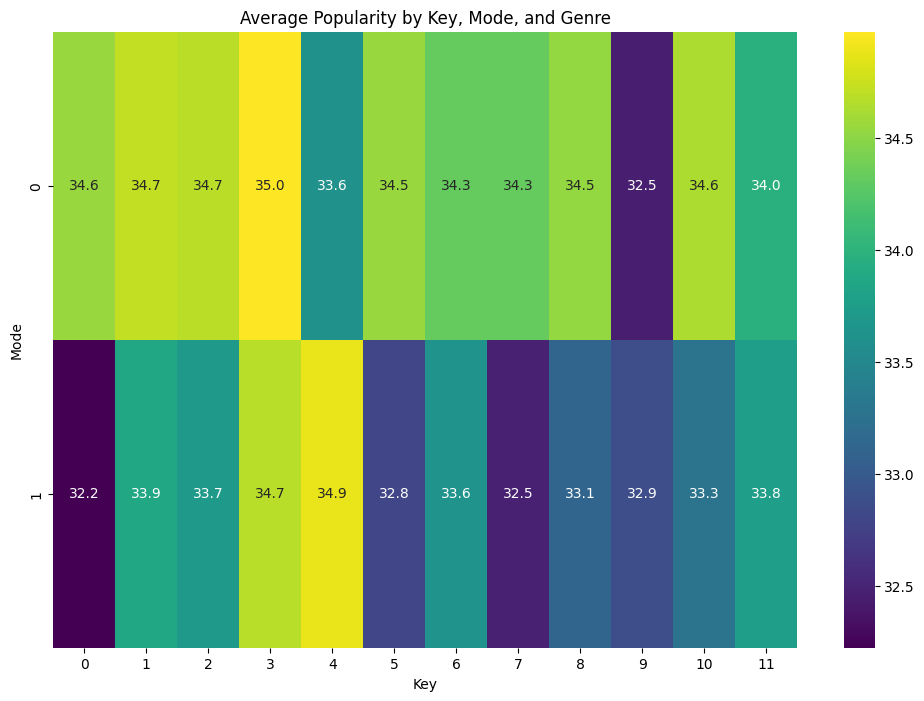

```python
# Group by key, mode, and genre and calculate the average popularity
grouped_data = df.groupby(['key', 'mode', 'track_genre'])['popularity'].mean().reset_index()

# Pivot the data to create a heatmap
pivot_data = grouped_data.pivot_table(index='mode', columns='key', values='popularity', aggfunc='mean')

# Plot heatmap
plt.figure(figsize=(12, 8))
sns.heatmap(pivot_data, cmap='viridis', annot=True, fmt=".1f")

# Customize labels and title
plt.xlabel('Key')
plt.ylabel('Mode')
plt.title('Average Popularity by Key, Mode, and Genre')

# Show plot
plt.show()
```

The heatmap visually represents the average popularity of music tracks categorized by their key and mode. Each cell in the heatmap corresponds to a combination of key and mode, where the color intensity indicates the average popularity level. The x-axis represents different musical keys, while the y-axis represents the mode (major or minor).

Though not directly shown in the heatmap, the initial grouping by 'track_genre' likely influences the popularity values. Certain genres might have higher average popularity across different key-mode combinations.

#### 3.5 Box Plot of Common Features in Songs

```python
# Filter the DataFrame based on popularity level
df_low = df[df['popularity'] <= 20]
df_high = df[df['popularity'] >= 80]

# Create a DataFrame for each feature for popularity <= 20
df_danceability = df_low[['danceability']]
df_energy = df_low[['energy']]
df_loudness = df_low[['loudness']]
df_speechiness = df_low[['speechiness']]
df_acousticness = df_low[['acousticness']]
df_instrumentalness = df_low[['instrumentalness']]
df_valence = df_low[['valence']]
df_tempo = df_low[['tempo']]

# Create a DataFrame for each feature for popularity >= 80
df_danceability1 = df_high[['danceability']]
df_energy1 = df_high[['energy']]
df_loudness1 = df_high[['loudness']]
df_speechiness1 = df_high[['speechiness']]
df_acousticness1 = df_high[['acousticness']]
df_instrumentalness1 = df_high[['instrumentalness']]
df_valence1 = df_high[['valence']]
df_tempo1 = df_high[['tempo']]
```

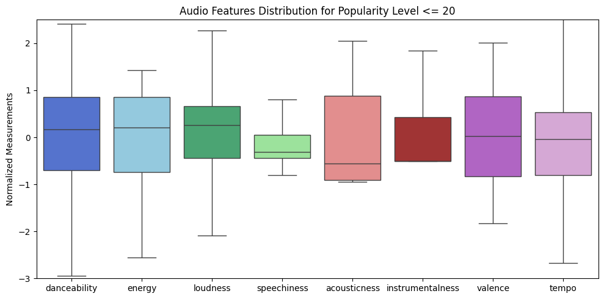

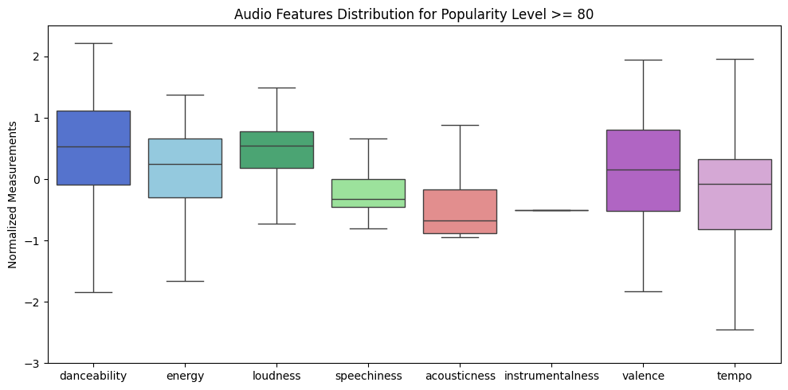

```python
# Create a plot for popularity <= 20
plt.figure(figsize=(10, 5))
plt.title("Audio Features Distribution for Popularity Level <= 20")
plt.ylabel("Normalized Measurements")
plt.ylim(-3, 2.5)
plt.grid(False)

sns.boxplot(data=df_danceability, color='royalblue', showfliers=False) # Danceability
sns.boxplot(data=df_energy, color='skyblue', showfliers=False) # Energy
sns.boxplot(data=df_loudness, color='mediumseagreen', showfliers=False) # Loudness
sns.boxplot(data=df_speechiness, color='lightgreen', showfliers=False) # Speechiness
sns.boxplot(data=df_acousticness, color='lightcoral', showfliers=False) # Acousticness
sns.boxplot(data=df_instrumentalness, color='firebrick', showfliers=False) # Instrumentalness
sns.boxplot(data=df_valence, color='mediumorchid', showfliers=False) # Valence
sns.boxplot(data=df_tempo, color='plum', showfliers=False) # Tempo

plt.tight_layout()
plt.show()

# Create a plot for popularity >= 80
plt.figure(figsize=(10, 5))
plt.title("Audio Features Distribution for Popularity Level >= 80")
plt.ylabel("Normalized Measurements")
plt.ylim(-3, 2.5)
plt.grid(False)

sns.boxplot(data=df_danceability1, color='royalblue', showfliers=False) # Danceability
sns.boxplot(data=df_energy1, color='skyblue', showfliers=False) # Energy
sns.boxplot(data=df_loudness1, color='mediumseagreen', showfliers=False) # Loudness
sns.boxplot(data=df_speechiness1, color='lightgreen', showfliers=False) # Speechiness
sns.boxplot(data=df_acousticness1, color='lightcoral', showfliers=False) # Acousticness
sns.boxplot(data=df_instrumentalness1, color='firebrick', showfliers=False) # Instrumentalness
sns.boxplot(data=df_valence1, color='mediumorchid', showfliers=False) # Valence
sns.boxplot(data=df_tempo1, color='plum', showfliers=False) # Tempo

plt.tight_layout()
plt.show()
```

#### 3.7 Exploratory Data Analysis Conclusions

These data visualizations help us understand the data more insightfully and effectively. Our analysis reveals various key factors that contribute to a song's popularity, with some factors being more impactful than others.

For instance, while pop-film songs have the highest portion of popular songs, this advantage is only marginal compared to the nine other popular genres. This suggests that genre might not be the most critical factor in determining a song's popularity. On the other hand, the Audio Features Distribution provides more significant insights. We observe that popular songs tend to have almost no instrumentalness, whereas this characteristic varies greatly for unpopular songs. By comparing the box plots more closely, we can identify similar trends in both plots.

Through these data visualizations, we aim to make our findings as clear and accessible as possible. We highly recommend incorporating data visualization into your analysis process to avoid scope creep, which involves attempting to use too much data. Our code indicates that we should focus solely on the audio features of our songs for the machine learning portion of the project. To learn more about how to avoid scope creep, you can refer to this resource: [Scope Creep: A Data Analyst's Guide to Prevention and Mitigation](https://www.linkedin.com/pulse/scope-creep-data-analysts-guide-prevention-mitigation-henry-madanga/)

### **4. Hypothesis Testing**

The code below performs hypothesis testing on selected features to determine their significance in predicting song popularity. The dataset is divided into two groups: songs with low popularity (popularity ≤ 50) and songs with high popularity (popularity > 50). The selected features for this analysis are danceability, energy, loudness, speechiness, acousticness, instrumentalness, valence, and tempo.

For each feature, the mean and variance are calculated for both low and high popularity groups. A t-test is then performed to compare the means between the two groups, assuming equal variances. The t-statistic and p-value are obtained to determine the significance of the difference. An alpha level of 0.05 is used for the decision criterion.

#### 4.1 Imports

```python
import scipy.stats as stats
```

#### 4.2 Null v. Alternative Hypothesis

To further understand our Audio Features distribution chart that we created above, we will be exploring the null hypothesis that there is no significant difference in any audio feature between low and high popularity groups. Our alternative hypothesis would be that there in fact *is* a significant difference in some or all audio features between low and high popularity groups. To do this, we will begin by creating two groups based on popularity (50 or under and 51 or over).

```python
popularity_low = df[df['popularity'] <= 50]
popularity_high = df[df['popularity'] > 50]
```

We will then choose the features that we would like to test.

```python
selected_features = ['danceability', 'energy', 'loudness', 'speechiness', 'acousticness', 'instrumentalness', 'valence', 'tempo']
```

Lastly, we will go through each feature and conduct an individual hypothesis test for each so that we can determine which features are significant.

```python
# Perform a hypothesis test for each selected feature
for feature in selected_features:
    low_mean = popularity_low[feature].mean()
    high_mean = popularity_high[feature].mean()
    low_var = popularity_low[feature].var()
    high_var = popularity_high[feature].var()

    # Assuming equal variances, use a t-test
    t_stat, p_val = stats.ttest_ind(popularity_low[feature], popularity_high[feature], equal_var=True)

    print("Feature:", feature)
    print("Low Popularity Group: Mean =", low_mean, ", Variance =", low_var)
    print("High Popularity Group: Mean =", high_mean, ", Variance =", high_var)
    print("T-statistic:", t_stat)
    print("P-value:", p_val)
    print("")

    # Decision based on p-value
    alpha = 0.05
    if p_val < alpha:
        print("Reject null hypothesis: There is a significant difference in", feature, "between low and high popularity groups.")
    else:
        print("Fail to reject null hypothesis: There is no significant difference in", feature, "between low and high popularity groups.")
    print("\n---\n")
```

```
Feature: danceability
Low Popularity Group: Mean = -0.02953233442891901 , Variance = 1.0385575373537959
High Popularity Group: Mean = 0.09170124830649067 , Variance = 0.8692259014332402
T-statistic: -17.594303910443102
P-value: 3.364104753711781e-69

Reject null hypothesis: There is a significant difference in danceability between low and high popularity groups.

---

Feature: energy
Low Popularity Group: Mean = 0.012639900787925514 , Variance = 1.028020222450532
High Popularity Group: Mean = -0.03924832571271169 , Variance = 0.9110273301565404
T-statistic: 7.52206121867877
P-value: 5.431246346235214e-14

Reject null hypothesis: There is a significant difference in energy between low and high popularity groups.

---

Feature: loudness
Low Popularity Group: Mean = -0.019456815355354998 , Variance = 0.9873176415556184
High Popularity Group: Mean = 0.06041561869920521 , Variance = 1.0346274294411086
T-statistic: -11.582774713768478
P-value: 5.244608162561827e-31

Reject null hypothesis: There is a significant difference in loudness between low and high popularity groups.

---

Feature: speechiness
Low Popularity Group: Mean = 0.028024723659143345 , Variance = 1.1531372896270233
High Popularity Group: Mean = -0.08701994585539313 , Variance = 0.5145402173687138
T-statistic: 16.69386860481747
P-value: 1.7237926466849062e-62

Reject null hypothesis: There is a significant difference in speechiness between low and high popularity groups.

---

```

[output cut: 24 more lines]

```
P-value: 4.500137429528557e-42

Reject null hypothesis: There is a significant difference in valence between low and high popularity groups.

---

Feature: tempo
Low Popularity Group: Mean = 0.007466833915059211 , Variance = 1.0183093246217545
High Popularity Group: Mean = -0.023185366282376264 , Variance = 0.9425073968741234
T-statistic: 4.442828341085273
P-value: 8.886743804423353e-06

Reject null hypothesis: There is a significant difference in tempo between low and high popularity groups.

---
```

### **5. Machine Learning: Can we predict the popularity of a song based on the given data?**

In this section of our project, we delve into the realm of machine learning to address a fundamental question: Can we accurately predict the popularity of a song based on its inherent musical features? Leveraging our dataset, we embark on a binary classification task, distinguishing songs with low popularity (50 or less) from those with high popularity (above 50).

By harnessing advanced machine learning algorithms and techniques, we aim to develop a predictive model capable of discerning the distinguishing characteristics that contribute to a song's popularity. Through meticulous feature selection, model training, and evaluation, we endeavor to uncover meaningful insights into the underlying factors driving the success of music in the digital age.

Our exploration into predictive modeling not only serves to validate our hypotheses regarding the determinants of song popularity but also holds significant implications for artists, producers, and industry stakeholders seeking to optimize their creative endeavors and enhance their chances of achieving widespread acclaim and recognition.

```python
from sklearn.model_selection import train_test_split
from sklearn.preprocessing import StandardScaler
from sklearn.impute import SimpleImputer
from sklearn.pipeline import Pipeline
from sklearn.linear_model import LogisticRegression
from sklearn.ensemble import RandomForestClassifier
from sklearn.svm import SVC
from sklearn.metrics import classification_report, confusion_matrix, accuracy_score
```

We will begin by defining a binary target variable: 1 if popularity > 50 (popular song) and 0 if popularity <= 50 (unpopular song).

```python
df['pop_song'] = (df['popularity'] > 50).astype(int)
```

```python
significant_features = ['danceability', 'energy', 'loudness', 'speechiness', 'acousticness', 'instrumentalness']
target_variable = 'pop_song'
```

Next, we split the data into features and target variables, separate it into training and testing sets, and create a preprocessing pipeline to handle missing values and scale the data. This pipeline will be applied to both the training and testing data.

```python
# Split the data into features (X) and target (y)
X = df[significant_features]
y = df[target_variable]

# Split the data into training and testing sets
X_train, X_test, y_train, y_test = train_test_split(X, y, test_size=0.2, random_state=42)

# Create a pipeline for processing the data
num_pipeline = Pipeline([
    ('imputer', SimpleImputer(strategy="mean")),
    ('scaler', StandardScaler())
])

# Fit and transform the training data
X_train_prepared = num_pipeline.fit_transform(X_train)

# Transform the testing data
X_test_prepared = num_pipeline.transform(X_test)
```

Now for the ML! This code trains and evaluates logistic regression, random forest, and support vector machine models on the preprocessed training data, then predicts and assesses their performance on the test data using accuracy, confusion matrix, and classification report metrics.

```python
# Train and evaluate logistic regression model
log_reg = LogisticRegression()
log_reg.fit(X_train_prepared, y_train)
y_pred_log_reg = log_reg.predict(X_test_prepared)
print("Logistic Regression:")
print("Accuracy: ", accuracy_score(y_test, y_pred_log_reg))
print("Confusion Matrix:\n", confusion_matrix(y_test, y_pred_log_reg))
print("Classification Report:\n", classification_report(y_test, y_pred_log_reg, zero_division=0))

# Train and evaluate Random Forest model
rf_clf = RandomForestClassifier()
rf_clf.fit(X_train_prepared, y_train)
y_pred_rf = rf_clf.predict(X_test_prepared)
print("Random Forest Classifier:")
print("Accuracy: ", accuracy_score(y_test, y_pred_rf))
print("Confusion Matrix:\n", confusion_matrix(y_test, y_pred_rf))
print("Classification Report:\n", classification_report(y_test, y_pred_rf, zero_division=0))

# Train and evaluate SVM model
svc_clf = SVC()
svc_clf.fit(X_train_prepared, y_train)
y_pred_svc = svc_clf.predict(X_test_prepared)
print("Support Vector Classifier:")
print("Accuracy: ", accuracy_score(y_test, y_pred_svc))
print("Confusion Matrix:\n", confusion_matrix(y_test, y_pred_svc))
print("Classification Report:\n", classification_report(y_test, y_pred_svc, zero_division=0))
```

```
Logistic Regression:
Accuracy:  0.7593421052631579
Confusion Matrix:
 [[17313     0]
 [ 5487     0]]
Classification Report:
               precision    recall  f1-score   support

           0       0.76      1.00      0.86     17313
           1       0.00      0.00      0.00      5487

    accuracy                           0.76     22800
   macro avg       0.38      0.50      0.43     22800
weighted avg       0.58      0.76      0.66     22800

Random Forest Classifier:
Accuracy:  0.8550877192982456
Confusion Matrix:
 [[16899   414]
 [ 2890  2597]]
Classification Report:
               precision    recall  f1-score   support

           0       0.85      0.98      0.91     17313
           1       0.86      0.47      0.61      5487

    accuracy                           0.86     22800
   macro avg       0.86      0.72      0.76     22800
weighted avg       0.86      0.86      0.84     22800

Support Vector Classifier:
Accuracy:  0.7600438596491228
Confusion Matrix:
 [[17294    19]
 [ 5452    35]]
Classification Report:
               precision    recall  f1-score   support

           0       0.76      1.00      0.86     17313
           1       0.65      0.01      0.01      5487

    accuracy                           0.76     22800
   macro avg       0.70      0.50      0.44     22800
weighted avg       0.73      0.76      0.66     22800
```

The logistic regression model seems to be performing relatively well in terms of overall accuracy, achieving around 76% accuracy on the test set. However, a deeper analysis reveals significant limitations:

- The dataset suffers from class imbalance, where the majority class (low popularity) greatly outnumbers the minority class (high popularity). This class imbalance is evident in the confusion matrix, where all predictions are classified as the majority class (0 - low popularity). As a result, the model fails to predict any instances of high popularity correctly, leading to poor recall and F1-score for the minority class.
- The precision, recall, and F1-score for the minority class (high popularity) are all zero, indicating that the model fails to correctly identify any instances of high popularity. This suggests that the logistic regression model struggles to capture the underlying patterns and nuances that differentiate high-popularity songs from low-popularity ones based on the selected features.
- The analysis does not provide insights into the importance of individual features in predicting song popularity. Understanding which features are most influential could guide feature selection and model refinement efforts, potentially improving predictive performance.
- While accuracy is a commonly used metric for evaluating classifier performance, it can be misleading in the presence of imbalanced classes. Additional metrics such as precision, recall, and F1-score provide a more nuanced understanding of model performance, especially in scenarios with imbalanced datasets.

In summary, while the logistic regression model demonstrates decent overall accuracy, its inability to correctly predict instances of high popularity highlights the need for further model refinement, feature engineering, and potentially exploring alternative modeling approaches better suited to handle imbalanced datasets, such as ensemble methods or resampling techniques. Additionally, deeper analysis into feature importance and model evaluation metrics can provide valuable insights for improving model performance.